```r
rm(list = ls())
library(dplyr)
library(stringr)
library(plyr)
library(reshape2)
library(htmlTable)
library(foreach)
library(doMC)
library(magrittr)
library(readr)
registerDoMC(cores = 3)

source("rep.corr.func.R")
use.repurp.annots <- F
permute.moas <- F
seed.moa <- -8     ## ignore, if permute.moas is False
LUAD <- F
LUAD.mut <- F
just.bioactives <- T
no.top.matches <- 30
cor.thr <- 0.25
p.val.thr <- 0.005
N <- 200                     ## number of Monte-carlo simulations to estimate expected random matches
genes.to.remove <- c()        ## remove these genes before making matches

base.dir <- "2016-07-20_90b7bb86"
use.feat.selected.in.TA.ORF.in.common <- F
corr.type <- "pearson"

if (LUAD) {
  load("../input/LUAD/LUAD.RData")
  Pf.ta <- list(data = Px, factor_cols = "Metadata_x_mutation_status", feat_cols = setdiff(colnames(Px), "Metadata_x_mutation_status"))
  Pf.ta.all <- Pf
  Pf.ta$data <- Pf.ta$data %>% dplyr::filter(str_detect(Metadata_x_mutation_status, "WT")) %>% dplyr::mutate(Treatment = Metadata_x_mutation_status)
  Pf.ta$factor_cols <- c(Pf.ta$factor_cols, "Treatment")
  Pf.ta.all$data <- Pf.ta.all$data %>% dplyr::filter(str_detect(Metadata_x_mutation_status, "WT")) %>% dplyr::mutate(Treatment = Metadata_x_mutation_status)
  Pf.ta.all$factor_cols <- c(Pf.ta.all$factor_cols, "Treatment")

  Pf.ta$data$Treatment <- lapply(Pf.ta$data$Treatment, function(x) (str_split(x, "_")[[1]][1])) %>% unlist
  Pf.ta.all$data$Treatment <- lapply(Pf.ta.all$data$Treatment, function(x) (str_split(x, "_")[[1]][1])) %>% unlist
  Pf.ta$data <- Pf.ta$data %>% dplyr::group_by(Treatment) %>% slice(1) %>% dplyr::ungroup()
} else if (LUAD.mut) {
  load("../input/LUAD/LUAD.RData")
  Pf.ta <- list(data = Px, factor_cols = "Metadata_x_mutation_status", feat_cols = setdiff(colnames(Px), "Metadata_x_mutation_status"))
  Pf.ta.all <- Pf
  a <- read.csv("../input/LUAD/allele_classification.csv")
  GOF <- a$Allele[which(a$Benchmark.activity == "GOF" | a$eVIP_prediction %in% c("GOF", "Neutral"))]
  s <- Pf.ta$data$Metadata_x_mutation_status %>% unique
  s <- s[which(str_detect(s, "_WT"))]
  GOF <- c(as.character(GOF), as.character(s))

  Pf.ta$data <- Pf.ta$data %>% dplyr::filter(Metadata_x_mutation_status %in% GOF) %>% dplyr::mutate(Treatment = Metadata_x_mutation_status)
  Pf.ta$factor_cols <- c(Pf.ta$factor_cols, "Treatment")
  Pf.ta.all$data <- Pf.ta.all$data %>% dplyr::filter(str_detect(Metadata_x_mutation_status, "WT")) %>% dplyr::mutate(Treatment = Metadata_x_mutation_status)
  Pf.ta.all$factor_cols <- c(Pf.ta.all$factor_cols, "Treatment")

  Pf.ta$data$Treatment <- lapply(Pf.ta$data$Treatment, function(x) (str_split(x, "_")[[1]][1])) %>% unlist
  Pf.ta.all$data$Treatment <- lapply(Pf.ta.all$data$Treatment, function(x) (str_split(x, "_")[[1]][1])) %>% unlist
  Pf.ta$data <- dplyr::left_join(Pf.ta$data, uu, by = "Metadata_x_mutation_status")
  Pf.ta$factor_cols <- c(Pf.ta$factor_cols, "strn")
  Pf.ta$data <- Pf.ta$data %>% dplyr::group_by(Treatment) %>% arrange(-strn) %>% slice(1) %>% dplyr::ungroup()
  Pf.ta$data %>% dplyr::select(Treatment, Metadata_x_mutation_status, strn) %>% unique %>% knitr::kable()
} else {
  load("../input/TA/Initial_analysis_workspace_new.RData")
  Pf.ta <- Pf_org.org.collapsed
  Pf.ta.all <- Pf_org.org
  strong.trt <- Pf.trt.strong.collapsed$data$Treatment
  data.annot <- Pf.strong %>% dplyr::filter(Treatment %in% strong.trt) %>% dplyr::select(one_of(c("Treatment", "Pathway", "Gene", "AlleleDesc"))) %>%
    dplyr::mutate(Pathway = str_replace(Pathway, "Canonical ", "")) %>%
    dplyr::mutate(AlleleDesc = str_sub(AlleleDesc, 1, 2)) %>%
    dplyr::filter(AlleleDesc == "WT") %>% dplyr::group_by(Gene) %>% dplyr::slice(1) %>%
    dplyr::ungroup()
  desired.ta <- data.annot$Treatment
  Pf.ta.all$data <- Pf.ta.all$data %>% dplyr::filter(Treatment %in% c(as.character(desired.ta), "EMPTY_"))
  Pf.ta$data <- Pf.ta$data %>% dplyr::filter(Treatment %in% desired.ta)

  Pf.ta$data <- Pf.ta$data %>% dplyr::filter(Treatment %in% desired.ta)
  Pf.ta$data$Treatment <- lapply(Pf.ta$data$Treatment, function(x) (str_split(x, "_")[[1]][1])) %>% unlist
}

Pf.gene <- Pf.ta
Pf.gene.all <- Pf.ta.all
Pf.gene$data <- Pf.gene$data %>% dplyr::filter(! Treatment %in% genes.to.remove)


############

Pf.cmpd <- readRDS("../results/master/2017-04-20_64917c8b/Pf_annotated.rds")
Pf.cmpd$data %<>% mutate(CPD_NAME = ifelse(CPD_NAME != "", CPD_NAME, Metadata_broad_sample))

source("rep.corr.func.R")
Pf.1 <- readRDS("../results/master/2017-04-20_425d653/Pf_bio_new.rds")
if (!just.bioactives) {
  Pf.2 <- readRDS("../results/master/2017-04-20_425d653/Pf_DOS_new.rds")
  Pf <- rbind(Pf.1, Pf.2)
} else {
  Pf <- Pf.1
}

u <- rep.cor(list(data = Pf, feat_cols = Pf.cmpd$feat_cols, factor_cols = Pf.cmpd$factor_cols), grp.var = "Metadata_broad_sample", feat.var = Pf.cmpd$feat_cols)
up <- readr::read_csv("../results/master/2017-04-21_425d6537/Cell_counts.csv")
```

```r
x <- Pf %>%
  left_join(., u, by = "Metadata_broad_sample") %>%
  left_join(., up, by = c("Metadata_Plate" = "Image_Metadata_Plate", "Metadata_Well" = "Image_Metadata_Well")) %>%
  select(Metadata_broad_sample, cr, Image_Count_Cells) %>%
  group_by(Metadata_broad_sample) %>%
  summarise_each(funs(mean))

Pf.cmpd$data %<>%
  right_join(., x, by = "Metadata_broad_sample") %>%
  mutate(rep.corr = round(cr, 2), Mean_Cells_Count = round(Image_Count_Cells, 2)) %>%
  select(-cr, -Image_Count_Cells)

Pf.cmpd$factor_cols <- c(Pf.cmpd$factor_cols, "rep.corr", "Mean_Cells_Count")
Pf.cmpd$data$Mean_Cells_Count <- round(scale(Pf.cmpd$data$Mean_Cells_Count), 2)
```

```r
f1 <- Pf.cmpd$feat_cols
f2 <- Pf.gene$feat_cols
f <- intersect(f1, f2)

Pf.cmpd$feat_cols <- f
Pf.gene$feat_cols <- f

Pf.cmpd$data <- Pf.cmpd$data[,c(Pf.cmpd$factor_cols, Pf.cmpd$feat_cols)]
Pf.gene$data <- Pf.gene$data[,c(Pf.gene$factor_cols, Pf.gene$feat_cols)]

if (use.feat.selected.in.TA.ORF.in.common) {
  feats <- Pf_org$feat_cols
  feats <- intersect(feats, Pf.cmpd$feat_cols)
  Pf.cmpd$feat_cols <- feats
  Pf.cmpd$data <- Pf.cmpd$data[,c(feats, Pf.cmpd$factor_cols)]
  Pf.gene$feat_cols <- feats
  Pf.gene$data <- Pf.gene$data[,c(feats, Pf.gene$factor_cols)]
}

print(length(Pf.cmpd$feat_cols))
```

```
## [1] 605
```

```r
print(NROW(Pf.cmpd$data))
```

```
## [1] 1174
```

```r
print(length(Pf.gene$feat_cols))
```

```
## [1] 605
```

```r
print(NROW(Pf.gene$data))
```

```
## [1] 69
```

```r
cr <- cor(Pf.cmpd$data[,Pf.cmpd$feat_cols] %>% t, Pf.gene$data[,Pf.gene$feat_cols] %>% t)
rownames(cr) <- Pf.cmpd$data$CPD_NAME
colnames(cr) <- Pf.gene$data$Treatment
cr.melt <- melt(cr)
```

```r
source("../l1ktools/R/cmap/io.R")
ds <- parse.gctx("../results/manual/cmap.compound.score/result_WTCS.LM.COMBINED_n328x22962.gctx", set_annot_rownames = F)
```

```
## reading ../results/manual/cmap.compound.score/result_WTCS.LM.COMBINED_n328x22962.gctx
```

```r
cmpd.gene.score.cmap <- attr(ds, "mat")
rn <- rownames(cmpd.gene.score.cmap)
rn <- sapply(str_split(rn, ":"), "[[", 2)
rownames(cmpd.gene.score.cmap) <- rn
rn.cmap <- rn

cn <- colnames(cmpd.gene.score.cmap)
cn <- sapply(str_split(cn, ":"), "[[", 2)
colnames(cmpd.gene.score.cmap) <- cn


meta.ta.cmap <- read.csv("../input/TA-OE-L1000-B1/TA.OE005_U2OS_72H_COMPZ.MODZ_SCORE_LM_n323x978.gctx.gct.csv") %>% t
colnames(meta.ta.cmap) <- meta.ta.cmap[1,]
meta.ta.cmap <- meta.ta.cmap[-1,]
meta.ta.cmap <- meta.ta.cmap %>% as.data.frame()
genes.ta.cmap <- meta.ta.cmap$x_genesymbol_mutation
ids.ta.cmap <- meta.ta.cmap$pert_id
meta.ta.cmap[, "det_well"] <- tolower(meta.ta.cmap$det_well)
treatment.meta <- Pf_org$data %>%
  dplyr::filter(Type == "Treated") %>%
  dplyr::select(Well, Treatment) %>%
  unique %>%
  dplyr::left_join(., meta.ta.cmap, by = c("Well" = "det_well"))
treatment.meta <- treatment.meta %>% dplyr::filter(!Treatment %in% c("CYLD_WT", "ERG_truncated"))

treatment.to.id <- data.frame(treatment.meta$pert_id)
rownames(treatment.to.id) <- treatment.meta$Treatment
id.to.treatment <- data.frame(treatment.meta$Treatment)
ix <- which(is.na(treatment.meta$pert_id))
treatment.meta$pert_id <- treatment.meta$pert_id %>% as.character()
treatment.meta$pert_id[ix] <- 1:length(ix)
rownames(id.to.treatment) <- treatment.meta$pert_id

colnames(cmpd.gene.score.cmap) <- id.to.treatment[cn, ]
cmpd.gene.score.cmap <- cmpd.gene.score.cmap[,intersect(desired.ta, colnames(cmpd.gene.score.cmap))]
colnames(cmpd.gene.score.cmap) <- lapply(colnames(cmpd.gene.score.cmap), function(x) str_split(x, "_")[[1]][1]) %>% unlist
u <- cmpd.gene.score.cmap
cr.l1000 <- u
rownames(cr.l1000) <- rownames(cmpd.gene.score.cmap)

cr.melt.l1000 <- cr.l1000 %>%
  reshape2::melt(.)

cr.melt.l1000.ext <- cr.melt.l1000 %>%
  dplyr::left_join(., Pf.cmpd$data[,c("Metadata_broad_sample","CPD_NAME")],
                   by = c("Var1" = "Metadata_broad_sample")) %>%
  dplyr::select(-Var1) %>%
  dplyr::rename(Var1 = CPD_NAME) %>%
  dplyr::filter(Var1 %in% rownames(cr))
cr.melt <- cr.melt.l1000.ext
```

```r
moas <- read.csv("../input/moas.txt", sep = "\t")

get.interacting.proteins <- function(protein.name) {
  dr <- "../results/manual/ppis"
  if (!dir.exists(dr)) {
    system(sprintf("mkdir -p %s", dr))
  }
  f.name <- sprintf("%s/%s.rds", dr, protein.name)
  if (file.exists(f.name)) {
    return(readRDS(f.name))
  }

  tbl <- read.table(sprintf("http://webservice.thebiogrid.org/interactions/?searchNames=true&geneList=%s&taxId=9606&includeHeader=true&accesskey=ca950b072394ce1897811022f7757222", protein.name), sep="\t", header = FALSE, fill = T)
  tbl <- tbl[, c(8, 9, 12, 13, 14)]
  colnames(tbl) <- c("Protein.1", "Protein.2", "Method", "Type", "Evidence")
  saveRDS(tbl, f.name)
  return(tbl)
}

get.all.interacting.proteins <- function(protein.name) {
  res <- c()
  for (p in protein.name) {
    ppi <- tryCatch(get.interacting.proteins(p), error = function(e) {})
    res <- rbind(res, ppi)
  }
  return(res)
}

 V <- matrix(0, 2, 2)

sample.tot <- function(Pf.cmpd, Pf.gene, random.shuffle = F, random.shuffle.genes = F, random.shuffle.cmpds = F, verbose = F, cor.thr = 0.5, how.many = 5) {
  gn.list <- c()
  gn.map <- Pf.gene$data$Treatment %>% as.matrix() %>% as.vector()
  if (random.shuffle.genes) {
    while(T) {
      names(gn.map) <- gn.map[permute::shuffle(length(gn.map))]
      flag <- T
      for (i in 1:length(cls.gene)) {
        if (any(gn.map[cls.gene[[i]]] %in% cls.gene[[i]])) {
          flag <- F
          break
        }
      }
      if (flag) {
        break
      }
    }
  } else {
    names(gn.map) <- gn.map
  }

  if (random.shuffle.cmpds) {
    Pf.cmpd$data[,"CPD_NAME"] <- Pf.cmpd$data[permute::shuffle(NROW(Pf.cmpd$data)), "CPD_NAME"]
  }

  all.targ <- lapply(Pf.cmpd$data$Target %>% unique, function(x) str_split(x, ", ")[[1]]) %>% do.call(c, .) %>% unique
  path <- sprintf("../results/manual/ppis")
  if (!dir.exists(path)) {
    system(sprintf("mkdir -p %s", path))
  }
  if (file.exists(sprintf("%s/all.rds", path))) {
    ppi.all <- readRDS(sprintf("%s/all.rds", path))
  } else {
    ppi.all <- tryCatch(get.all.interacting.proteins(all.targ), error = function(e) {})
    saveRDS(ppi.all, sprintf("%s/all.rds", path))
  }

  pb <- progress::progress_bar$new(total = length(Pf.gene$data$Treatment))
  for (gene in Pf.gene$data$Treatment) {
    if (verbose) {
      pb$tick()
    }
    gn <- gn.map[gene] %>% as.matrix() %>% as.vector()
    if (!random.shuffle) {
      u.res <- cr.melt %>%
        dplyr::filter(Var2 == gn) %>%
        dplyr::arrange(-value) %>%
        dplyr::mutate(value = round(value, 2)) %>% dplyr::filter(value > cor.thr)
        up.reg <- u.res %>% head(., how.many) %>% dplyr::filter(value > 0) %>% dplyr::select(Var1) %>% as.matrix() %>% as.vector()
        down.reg <- u.res %>% tail(., how.many) %>% dplyr::filter(value < 0) %>% dplyr::select(Var1) %>% as.matrix() %>% as.vector()

    } else {
      u.res <- cr.melt %>%
        dplyr::filter(Var2 == gn) %>%
        sample_n(NROW(.)) %>%
        dplyr::mutate(value = round(value, 2))
      up.reg <- u.res %>% head(., how.many) %>% dplyr::select(Var1) %>% as.matrix() %>% as.vector()
      down.reg <- u.res %>% tail(., how.many) %>% dplyr::select(Var1) %>% as.matrix() %>% as.vector()
    }

    reg <- c(up.reg, down.reg) %>% unique
    reg <- setdiff(reg, "")
    u.res.lim <- u.res %>% dplyr::filter(Var1 %in% reg) %>% dplyr::mutate(CPD_NAME = Var1) %>% dplyr::mutate(Corr. = value) %>% dplyr::select(one_of(c("CPD_NAME", "Corr.")))

    rest <- setdiff(Pf.cmpd$data$CPD_NAME %>% unique, reg)
    v <- lapply(Pf.cmpd$data$Target[Pf.cmpd$data$CPD_NAME %in% reg], function(x) str_split(x, ", ")[[1]]) %>% do.call(c, .)
    if (length(v) == 0) {
      next
    }
    u <- lapply(Pf.cmpd$data$Target[Pf.cmpd$data$CPD_NAME %in% rest], function(x) str_split(x, ", ")[[1]]) %>% do.call(c, .)

    main.targ <- data.frame(gene = v) %>% dplyr::group_by(gene) %>% tally() %>% dplyr::filter(gene != "") %>% dplyr::arrange(-n) %>% dplyr::select(gene) %>% as.matrix() %>% as.vector()
    rest.targ <- data.frame(gene = u) %>% dplyr::group_by(gene) %>% tally() %>% dplyr::filter(gene != "") %>% dplyr::arrange(-n) %>% dplyr::select(gene) %>% as.matrix() %>% as.vector()

    ppi <- ppi.all %>% dplyr::filter(Protein.1 %in% main.targ | Protein.2 %in% main.targ)
    ppi2 <- ppi.all %>% dplyr::filter(Protein.1 %in% rest.targ | Protein.2 %in% rest.targ)

    id <- ppi %>% dplyr::filter(Protein.1 == gene | Protein.2 == gene) %>% unique %>% NROW
    id0 <- ppi2 %>% dplyr::filter(Protein.1 == gene | Protein.2 == gene) %>% unique %>% NROW
    Vi <- rbind(c(id, NROW(ppi %>% unique) - id), c(id0, NROW(ppi2 %>% unique) - id0))
    V <- V + Vi

    fsh <- fisher.test(Vi, alternative = "greater")
    if (fsh$p.value < p.val.thr/length(Pf.gene$data$Treatment)) {
      gn.list <- c(gn.list, gene)
      if (verbose) {
        cat(gene)
        cat("<br>")
        colnames(Vi) <- c("gene in relevant ppi", "otherwise")
        rownames(Vi) <- c("compound matches", "rest of compounds")
        Vi %>% htmlTable::htmlTable() %>% cat
        cat("<br>")
        fsh %>% print
        cat("<br>")
        #(Pf.cmpd$data %>% dplyr::filter(Name %in% reg) %>% dplyr::select(one_of(c("Name", "MOA", "Target")))) %>% plyr::join(., u.res.lim, by = "Name") %>% dplyr::arrange(Corr.) %>% htmlTable::htmlTable() %>% cat
        Pf.cmpd$data %>% dplyr::filter(CPD_NAME %in% reg) %>% dplyr::select(one_of(c("CPD_NAME", "MOA", "Target", "rep.corr", "Mean_Cells_Count"))) %>% dplyr::inner_join(., u.res.lim, by = "CPD_NAME") %>% arrange(Corr.) %>% htmlTable::htmlTable() %>% cat
        (ppi %>% dplyr::filter(Protein.1 == gene | Protein.2 == gene) %>% unique %>% head(., 20)) %>% htmlTable::htmlTable() %>% cat
        cat("<br> <hr>")
      }
    }

    if (verbose) {
      cr.l1000.melt <- cr.l1000 %>% reshape2::melt(.) %>% dplyr::filter(Var2 == gene)
      cat(gene, file = "predictions.html", append = T)
      cat("<br>", file = "predictions.html", append = T)
      Pf.cmpd$data %>% dplyr::filter(CPD_NAME %in% reg) %>% dplyr::select(one_of(c("CPD_NAME", "MOA", "Target", "rep.corr", "Mean_Cells_Count"))) %>% dplyr::inner_join(., u.res.lim, by = "CPD_NAME") %>% arrange(Corr.) %>% htmlTable::htmlTable() %>% cat(., file = "predictions.html", append = T)
      cat("<br> <hr>", file = "predictions.html", append = T)
    }
  }

  return(list(genes = gn.list, V = V))
}
```

```r
system("rm predictions.html")
res <- sample.tot(Pf.cmpd = Pf.cmpd, Pf.gene = Pf.gene, random.shuffle = F, random.shuffle.genes = F, random.shuffle.cmpds = F, verbose = T, cor.thr = cor.thr, how.many = no.top.matches)
```

BRAF

|  | gene in relevant ppi | otherwise |
| --- | --- | --- |
| compound matches | 77 | 2141 |
| rest of compounds | 24 | 34207 |

Fisher's Exact Test for Count Data

data: Vi p-value < 2.2e-16 alternative hypothesis: true odds ratio is greater than 1 95 percent confidence interval: 34.24882 Inf sample estimates: odds ratio 51.22822

|  | Metadata_broad_sample | CPD_NAME | MOA | Target | rep.corr | Mean_Cells_Count | Corr. |
| --- | --- | --- | --- | --- | --- | --- | --- |
| 1 | BRD-A67552019-001-02-2 | ouabain | ATPase inhibitor | ATP1A1, ATP1A2, ATP1A3, ATP1A4, ATP1B1, ATP1B2, ATP1B3, ATP1B4, FXYD2 | 0.27 | -2.7 | 0.31 |
| 2 | BRD-K35708212-331-03-1 | ouabain | ATPase inhibitor | ATP1A1, ATP1A2, ATP1A3, ATP1A4, ATP1B1, ATP1B2, ATP1B3, ATP1B4, FXYD2 | 0.43 | -2.73 | 0.31 |
| 3 | BRD-A34806832-001-02-7 | proscillaridin |  |  | 0.56 | -2.67 | 0.39 |
| 4 | BRD-K03067624-300-02-9 | emetine | protein synthesis inhibitor | RPS2 | 0.17 | 0.2 | 0.39 |
| 5 | BRD-K13265046-001-01-3 | beta-peltatin |  |  | 0.37 | -2.42 | 0.39 |
| 6 | BRD-K47150025-001-01-2 | BRD-K47150025-001-01-2 |  |  | 0.55 | -2.43 | 0.39 |
| 7 | BRD-K60476892-001-02-1 | yc-1 |  |  | 0.47 | -1.02 | 0.39 |
| 8 | BRD-K63606607-001-01-8 | bufalin |  |  | 0.25 | -2.72 | 0.39 |
| 9 | BRD-K69023402-001-02-5 | thapsigargin |  |  | 0.41 | -2.8 | 0.39 |
| 10 | BRD-A46684810-001-04-6 | BRD-A46684810-001-04-6 |  |  | 0.3 | -2.5 | 0.4 |
| 11 | BRD-A89434049-001-02-1 | sarmentogenin |  |  | 0.19 | -2.68 | 0.4 |
| 12 | BRD-K08438429-001-01-0 | BRD-K08438429-001-01-0 |  |  | 0.34 | -0.05 | 0.4 |
| 13 | BRD-K68143200-001-04-2 | nsc95397 | CDC inhibitor | CASP3, CDC25A, CDC25B | 0.47 | -2.79 | 0.4 |
| 14 | BRD-A05456882-001-01-7 | dichlorobenzimidazole riboside |  |  | 0.34 | 0.69 | 0.41 |
| 15 | BRD-A17065207-001-06-9 | BRD-A17065207-001-06-9 |  |  | 0.74 | -2.46 | 0.41 |
| 16 | BRD-A67552019-001-02-2 | ouabain | ATPase inhibitor | ATP1A1, ATP1A2, ATP1A3, ATP1A4, ATP1B1, ATP1B2, ATP1B3, ATP1B4, FXYD2 | 0.27 | -2.7 | 0.41 |
| 17 | BRD-A80968824-001-02-8 | convallatoxin |  |  | 0.31 | -2.69 | 0.41 |
| 18 | BRD-A91008255-001-02-8 | bepridil | calcium channel blocker | ATP1A1, CACNA1A, CACNA1C, CACNA1H, CACNA2D2, CALM1, KCNQ1, KCNQ4, PDE1A, PDE1B, SCN5A, TNNC1 | 0.42 | -1.05 | 0.41 |
| 19 | BRD-K35708212-331-03-1 | ouabain | ATPase inhibitor | ATP1A1, ATP1A2, ATP1A3, ATP1A4, ATP1B1, ATP1B2, ATP1B3, ATP1B4, FXYD2 | 0.43 | -2.73 | 0.41 |
| 20 | BRD-K74305673-001-01-3 | BRD-K74305673-001-01-3 |  |  | 0.33 | -2.22 | 0.41 |
| 21 | BRD-K76840893-003-01-7 | BRD-K76840893-003-01-7 |  |  | 0.15 | -1.9 | 0.41 |
| 22 | BRD-A54927599-001-07-8 | BRD-A54927599-001-07-8 |  |  | 0.45 | -2.22 | 0.42 |
| 23 | BRD-K23478508-001-03-7 | digoxin | ATPase inhibitor | ABCB1, ATP1A1, RORC, SLCO1B3 | 0.53 | -2.74 | 0.43 |
| 24 | BRD-K33882852-003-01-0 | BRD-K33882852-003-01-0 |  |  | 0.25 | -1.04 | 0.43 |
| 25 | BRD-K73789395-001-04-0 | zm336372 | RAF inhibitor | BRAF, LCK, MAPK14, RAF1 | 0.21 | -0.12 | 0.43 |
| 26 | BRD-K77947974-001-04-9 | fluspirilene | dopamine receptor antagonist | CACNG1, DRD2, HRH1, HTR1A, HTR1D, HTR1E, HTR2A | 0.37 | -2.02 | 0.43 |
| 27 | BRD-K15424032-001-01-0 | BRD-K15424032-001-01-0 |  |  | 0.38 | -0.86 | 0.45 |
| 28 | BRD-K36055864-001-04-4 | cicloheximide |  |  | 0.49 | -2.13 | 0.46 |
| 29 | BRD-K43744935-048-01-6 | BRD-K43744935-048-01-6 |  |  | 0.33 | -2.17 | 0.46 |
| 30 | BRD-K64246525-001-01-1 | BRD-K64246525-001-01-1 |  |  | 0.19 | 0.69 | 0.46 |
| 31 | BRD-A51381734-034-01-1 | BRD-A51381734-034-01-1 |  |  | 0.26 | -1.79 | 0.48 |
| 32 | BRD-A75769826-003-01-3 | BRD-A75769826-003-01-3 |  |  | 0.15 | 0.02 | 0.48 |
| 33 | BRD-K68552125-001-03-8 | phorbol myristate acetate |  |  | 0.34 | -0.16 | 0.53 |

|  | Protein.1 | Protein.2 | Method | Type | Evidence |
| --- | --- | --- | --- | --- | --- |
| 1 | MAP2K1 | BRAF | Affinity Capture-Western | physical | Loewenberg M (2006) |
| 2 | BRAF | MAP2K1 | Biochemical Activity | physical | Kilili GK (2010) |
| 3 | BRAF | MAP2K1 | Affinity Capture-Western | physical | Chen C (2008) |
| 4 | BRAF | MAP2K1 | Biochemical Activity | physical | Pardo OE (2006) |
| 5 | BRAF | MAP2K1 | Affinity Capture-MS | physical | Gloeckner CJ (2007) |
| 6 | MAP2K1 | BRAF | Affinity Capture-MS | physical | Gloeckner CJ (2007) |
| 7 | MAP2K1 | BRAF | Affinity Capture-MS | physical | Hein MY (2015) |
| 8 | BRAF | MAP2K2 | Affinity Capture-MS | physical | Gloeckner CJ (2007) |
| 9 | BRAF | HSPA5 | Affinity Capture-MS | physical | Gloeckner CJ (2007) |
| 10 | YWHAB | BRAF | Affinity Capture-MS | physical | Ewing RM (2007) |
| 11 | YWHAG | BRAF | Affinity Capture-MS | physical | Ewing RM (2007) |
| 12 | YWHAQ | BRAF | Affinity Capture-MS | physical | Ewing RM (2007) |
| 13 | YWHAZ | BRAF | Affinity Capture-MS | physical | Ewing RM (2007) |
| 14 | SFN | BRAF | Affinity Capture-MS | physical | Benzinger A (2005) |
| 15 | HRAS | BRAF | Two-hybrid | physical | Stang S (1997) |
| 16 | AKT1 | BRAF | Affinity Capture-Western | physical | Guan KL (2000) |
| 17 | BRAF | AKT1 | Affinity Capture-Western | physical | Guan KL (2000) |
| 18 | MAPK3 | BRAF | Phenotypic Enhancement | genetic | Guan KL (2000) |
| 19 | AKT1 | BRAF | Biochemical Activity | physical | Guan KL (2000) |
| 20 | BRAF | RAP1GAP | Reconstituted Complex | physical | Kao S (2001) |

CDKN1A

|  | gene in relevant ppi | otherwise |
| --- | --- | --- |
| compound matches | 88 | 7800 |
| rest of compounds | 93 | 33739 |

Fisher's Exact Test for Count Data

data: Vi p-value < 2.2e-16 alternative hypothesis: true odds ratio is greater than 1 95 percent confidence interval: 3.165768 Inf sample estimates: odds ratio 4.09277

|  | Metadata_broad_sample | CPD_NAME | MOA | Target | rep.corr | Mean_Cells_Count | Corr. |
| --- | --- | --- | --- | --- | --- | --- | --- |
| 1 | BRD-K51918615-303-01-1 | BRD-K51918615-303-01-1 |  |  | 0.39 | 0 | 0.38 |
| 2 | BRD-A22783572-065-01-3 | BRD-A22783572-065-01-3 |  |  | 0.63 | -2.36 | 0.39 |
| 3 | BRD-K13169950-001-04-5 | 5-nitroso-8-cinnolinol |  |  | 0.36 | -2.04 | 0.39 |
| 4 | BRD-K25433859-003-11-4 | maprotiline | norepinephrine reputake inhibitor, tricyclic antidepressant | ADRA1A, ADRA1B, ADRA1D, ADRA2A, ADRA2B, ADRA2C, CHRM1, CHRM2, CHRM3, CHRM4, CHRM5, DRD2, HRH1, HTR2A, HTR2C, HTR7, SLC6A2 | 0.21 | 0.46 | 0.39 |
| 5 | BRD-K48684885-001-01-8 | BRD-K48684885-001-01-8 |  |  | 0.6 | -2.72 | 0.39 |
| 6 | BRD-K03109492-001-01-4 | BRD-K03109492-001-01-4 |  |  | 0.14 | -2.82 | 0.4 |
| 7 | BRD-K06426971-001-01-9 | BRD-K06426971-001-01-9 |  |  | 0.32 | -2.76 | 0.4 |
| 8 | BRD-K17743125-001-01-9 | pxd101 |  |  | 0.48 | -2.63 | 0.4 |
| 9 | BRD-K25906698-303-01-9 | BRD-K25906698-303-01-9 |  |  | 0.16 | 1.21 | 0.4 |
| 10 | BRD-K50388907-001-04-9 | fenofibrate | PPAR receptor agonist | APOA1, CYP2C19, CYP2C8, MMP25, PPARA | 0.15 | 0.76 | 0.4 |
| 11 | BRD-A26222320-001-02-6 | puromycin | protein synthesis inhibitor | NHP2L1, RPL10L, RPL11, RPL13A, RPL15, RPL19, RPL23, RPL23A, RPL26L1, RPL3, RPL37, RPL8, RSL24D1 | 0.52 | -2.82 | 0.41 |
| 12 | BRD-K36007650-300-02-3 | puromycin | protein synthesis inhibitor | NHP2L1, RPL10L, RPL11, RPL13A, RPL15, RPL19, RPL23, RPL23A, RPL26L1, RPL3, RPL37, RPL8, RSL24D1 | 0.32 | -2.72 | 0.41 |
| 13 | BRD-K37561857-001-04-9 | zardaverine | phosphodiesterase inhibitor | PDE3A, PDE4A, PDE4B, PDE4C, PDE4D | 0.28 | -0.2 | 0.41 |
| 14 | BRD-K37848908-001-03-1 | ceforanide | penicillin binding protein inhibitor |  | 0.26 | -0.01 | 0.41 |
| 15 | BRD-K37865504-001-01-7 | ly-2183240 | FAAH inhibitor | FAAH | 0.48 | -2.51 | 0.41 |
| 16 | BRD-A46684810-001-04-6 | BRD-A46684810-001-04-6 |  |  | 0.3 | -2.5 | 0.43 |
| 17 | BRD-K41431477-001-05-6 | BRD-K41431477-001-05-6 |  |  | 0.28 | -2.77 | 0.43 |
| 18 | BRD-K50836978-001-01-7 | purvalanol a | CDK inhibitor | CCND1, CCNE1, CDK1, CDK2, CDK4, CDK5, CSNK1G3, RPS6KA1, SRC | 0.56 | -1.48 | 0.43 |
| 19 | BRD-K66898851-001-03-7 | sanguinarium chloride | apoptosis stimulant | ACHE, CASP3 | 0.47 | -2.79 | 0.44 |
| 20 | BRD-K27305650-001-04-2 | ly-294002 | mTOR inhibitor, PI3K inhibitor | AKT1, CHEK1, GSK3B, LCK, MAPK1, MAPK11, MAPK12, MAPK14, MAPK8, MTOR, PDE2A, PIK3CA, PIK3CB, PIK3CD, PIK3CG, PLK1, PRKCA, PRKDC, ROCK1, RPS6KB1, SGK1 | 0.39 | 0.1 | 0.45 |
| 21 | BRD-K54233340-300-01-0 | BRD-K54233340-300-01-0 |  |  | 0.47 | -1.83 | 0.45 |
| 22 | BRD-K08554278-001-02-4 | hoechst 33342 |  |  | 0.37 | -2.75 | 0.46 |
| 23 | BRD-K15025317-001-04-5 | bay 11-7082 | NFkB pathway inhibitor | RELA | 0.48 | -2.69 | 0.47 |
| 24 | BRD-K07762753-001-03-6 | aminopurvalanol a | CDK inhibitor, tyrosine kinase inhibitor | CDK1, CDK2, CDK5, CDK6 | 0.3 | -2.43 | 0.49 |
| 25 | BRD-K43389675-003-02-7 | daunorubicin | RNA synthesis inhibitor, topoisomerase inhibitor | TOP2A, TOP2B | 0.26 | -2.55 | 0.49 |
| 26 | BRD-A18497530-001-04-6 | 5-iodotubercidin |  |  | 0.58 | -2.13 | 0.5 |
| 27 | BRD-A37828317-001-02-2 | anthothecol |  |  | 0.73 | -2.65 | 0.51 |
| 28 | BRD-K39484304-001-02-5 | triptolide | RNA polymerase inhibitor | CYP2C19, RELA | 0.48 | -2.54 | 0.51 |
| 29 | BRD-K06543683-001-03-6 | ro 31-8220 |  |  | 0.36 | -2.19 | 0.53 |
| 30 | BRD-K11927976-050-01-1 | BRD-K11927976-050-01-1 |  |  | 0.33 | -2.42 | 0.53 |
| 31 | BRD-K21680192-300-05-2 | mitoxantrone | topoisomerase inhibitor | PIM1, TOP2A | 0.4 | -2.54 | 0.55 |

|  | Protein.1 | Protein.2 | Method | Type | Evidence |
| --- | --- | --- | --- | --- | --- |
| 1 | CDK1 | CDKN1A | Affinity Capture-Western | physical | Amador V (2007) |
| 2 | CDKN1A | CDK1 | Affinity Capture-Western | physical | Ando T (2001) |
| 3 | CDK1 | CDKN1A | Affinity Capture-Western | physical | Lin ML (2011) |
| 4 | CDK1 | CDKN1A | Affinity Capture-MS | physical | Varjosalo M (2013) |
| 5 | CDK1 | CDKN1A | Affinity Capture-MS | physical | Huttlin EL (2015) |
| 6 | CDKN1A | CDK1 | Affinity Capture-MS | physical | Hein MY (2015) |
| 7 | CDKN1A | CDK2 | Affinity Capture-Western | physical | Ono T (2000) |
| 8 | CDKN1A | CDK2 | Affinity Capture-Western | physical | McKenzie PP (2003) |
| 9 | CDKN1A | CDK2 | Reconstituted Complex | physical | McKenzie PP (2003) |
| 10 | CDK2 | CDKN1A | Affinity Capture-Western | physical | Law BK (2002) |
| 11 | CDK2 | CDKN1A | Two-hybrid | physical | Harper JW (1993) |
| 12 | CDK2 | CDKN1A | Reconstituted Complex | physical | Harper JW (1993) |
| 13 | CDKN1A | CDK2 | Reconstituted Complex | physical | Lacy ER (2005) |
| 14 | CDK2 | CDKN1A | Affinity Capture-Western | physical | Akagi M (1996) |
| 15 | CDKN1A | CDK2 | Affinity Capture-Western | physical | Zhao J (1998) |
| 16 | CDKN1A | CDK2 | Affinity Capture-Western | physical | Zhang Y (1999) |
| 17 | CDK2 | CDKN1A | Affinity Capture-Western | physical | Poon RY (1998) |
| 18 | CDKN1A | CDK2 | Affinity Capture-Western | physical | Gorospe M (1996) |
| 19 | CDK2 | CDKN1A | Affinity Capture-MS | physical | Varjosalo M (2013) |
| 21 | CDKN1A | CDK2 | Affinity Capture-MS | physical | Fogeron ML (2013) |

GSK3B

|  | gene in relevant ppi | otherwise |
| --- | --- | --- |
| compound matches | 443 | 5286 |
| rest of compounds | 443 | 32796 |

Fisher's Exact Test for Count Data

data: Vi p-value < 2.2e-16 alternative hypothesis: true odds ratio is greater than 1 95 percent confidence interval: 5.526154 Inf sample estimates: odds ratio 6.203852

|  | Metadata_broad_sample | CPD_NAME | MOA | Target | rep.corr | Mean_Cells_Count | Corr. |
| --- | --- | --- | --- | --- | --- | --- | --- |
| 1 | BRD-K47814830-001-02-6 | duartin |  |  | 0.16 | 0.72 | 0.3 |
| 2 | BRD-K78122587-300-01-9 | BRD-K78122587-300-01-9 |  |  | 0.21 | -2.83 | 0.3 |
| 3 | BRD-A70407468-001-01-2 | BRD-A70407468-001-01-2 |  |  | 0.25 | -0.08 | 0.31 |
| 4 | BRD-K40656405-001-01-5 | BRD-K40656405-001-01-5 |  |  | 0.17 | -0.24 | 0.31 |
| 5 | BRD-A50737080-001-01-4 | BRD-A50737080-001-01-4 |  |  | 0.35 | -1.83 | 0.32 |
| 6 | BRD-A68888262-003-02-9 | azelastine | histamine receptor antagonist | CYP2C19, HRH1 | 0.19 | 1.51 | 0.32 |
| 7 | BRD-K40742111-001-02-6 | baeomycesic acid |  |  | 0.3 | -0.52 | 0.32 |
| 8 | BRD-K61250553-001-02-9 | loperamide | opioid receptor agonist | CACNA1A, CALM1, CYP2B6, CYP2C8, NPR2, OPRD1, OPRK1, OPRM1, POMC | 0.27 | -0.77 | 0.32 |
| 9 | BRD-K76337122-001-02-9 | BRD-K76337122-001-02-9 |  |  | 0.27 | -0.75 | 0.32 |
| 10 | BRD-A01320529-001-05-9 | salmeterol | adrenergic receptor agonist | ADRB2 | 0.21 | 0.34 | 0.33 |
| 11 | BRD-A15914070-001-01-5 | BRD-A15914070-001-01-5 |  |  | 0.5 | -0.23 | 0.33 |
| 12 | BRD-A22684332-003-02-3 | procaterol | adrenergic receptor agonist | ADRB2 | 0.2 | 1.55 | 0.33 |
| 13 | BRD-K42500029-001-01-9 | BRD-K42500029-001-01-9 |  |  | 0.63 | -0.47 | 0.33 |
| 14 | BRD-K48684885-001-01-8 | BRD-K48684885-001-01-8 |  |  | 0.6 | -2.72 | 0.33 |
| 15 | BRD-K49294207-300-01-2 | BRD-K49294207-300-01-2 |  |  | 0.16 | -0.49 | 0.33 |
| 16 | BRD-K38477985-001-01-8 | BRD-K38477985-001-01-8 |  |  | 0.44 | -1.88 | 0.34 |
| 17 | BRD-K51575138-001-01-7 | BRD-K51575138-001-01-7 |  |  | 0.45 | -1.61 | 0.35 |
| 18 | BRD-K72703948-001-01-0 | BRD-K72703948-001-01-0 |  |  | 0.66 | -2.29 | 0.35 |
| 19 | BRD-K37865504-001-01-7 | ly-2183240 | FAAH inhibitor | FAAH | 0.48 | -2.51 | 0.36 |
| 20 | BRD-K42859542-001-01-7 | 1-(4'-aminophenyl)-3,5-dihydro-7,8-dimethoxy-4h-2,3-benzodiazepin-4-one |  |  | 0.41 | -0.36 | 0.36 |
| 21 | BRD-K09537769-001-01-6 | nu7026 | DNA dependent protein kinase inhibitor, mTOR inhibitor, PI3K inhibitor | PRKDC | 0.16 | 0.65 | 0.37 |
| 22 | BRD-K48735772-001-01-4 | BRD-K48735772-001-01-4 |  |  | 0.53 | -0.19 | 0.37 |
| 23 | BRD-K58938839-001-03-8 | cyclopamine |  |  | 0.41 | 0.03 | 0.37 |
| 24 | BRD-A37828317-001-02-2 | anthothecol |  |  | 0.73 | -2.65 | 0.38 |
| 25 | BRD-K72726508-001-01-3 | BRD-K72726508-001-01-3 |  |  | 0.56 | 0 | 0.38 |
| 26 | BRD-K01567962-001-06-5 | pyrazolanthrone | JNK inhibitor | LRRK2, MAPK10, MAPK8, MAPK8IP1, MAPK9, TTK | 0.46 | -1.35 | 0.39 |
| 27 | BRD-K44309363-003-01-3 | BRD-K44309363-003-01-3 |  |  | 0.26 | -2.52 | 0.39 |
| 28 | BRD-K67537649-001-01-1 | BRD-K67537649-001-01-1 |  |  | 0.42 | 0.19 | 0.41 |
| 29 | BRD-K27305650-001-04-2 | ly-294002 | mTOR inhibitor, PI3K inhibitor | AKT1, CHEK1, GSK3B, LCK, MAPK1, MAPK11, MAPK12, MAPK14, MAPK8, MTOR, PDE2A, PIK3CA, PIK3CB, PIK3CD, PIK3CG, PLK1, PRKCA, PRKDC, ROCK1, RPS6KB1, SGK1 | 0.39 | 0.1 | 0.42 |
| 30 | BRD-A11678676-001-02-6 | wortmannin | PI3K inhibitor | ATM, ATR, MTOR, PI4KA, PI4KB, PIK3CA, PIK3CD, PIK3CG, PIK3R1, PLK1, PLK3, PRKDC | 0.31 | 0.01 | 0.46 |

|  | Protein.1 | Protein.2 | Method | Type | Evidence |
| --- | --- | --- | --- | --- | --- |
| 1 | GSK3B | RELA | Affinity Capture-Western | physical | Neumann M (2011) |
| 2 | HDAC6 | GSK3B | Affinity Capture-Western | physical | Beurel E (2011) |
| 3 | GSK3B | TUBA1A | Two-hybrid | physical | Vinayagam A (2011) |
| 4 | AURKA | GSK3B | Affinity Capture-Western | physical | Kwon YW (2012) |
| 5 | AURKA | GSK3B | Affinity Capture-Western | physical | Chou CH (2013) |
| 6 | GSK3B | AURKA | Affinity Capture-Western | physical | Chou CH (2013) |
| 7 | GSK3B | HSP90AA1 | Biochemical Activity | physical | Muller P (2012) |
| 8 | GSK3B | XIAP | Affinity Capture-Western | physical | Sun M (2009) |
| 9 | GSK3B | PDE4D | Biochemical Activity | physical | Zhu H (2010) |
| 10 | TOP2A | GSK3B | Affinity Capture-Western | physical | Chen MC (2011) |
| 11 | GSK3B | AR | Reconstituted Complex | physical | Wang L (2004) |
| 12 | GSK3B | AR | Affinity Capture-Western | physical | Wang L (2004) |
| 13 | GSK3B | NFKB1 | Biochemical Activity | physical | Demarchi F (2001) |
| 14 | GSK3B | TP53 | Two-hybrid | physical | Vinayagam A (2011) |
| 15 | GSK3B | PSEN1 | Biochemical Activity | physical | Prager K (2007) |
| 16 | GSK3B | DNMT1 | Two-hybrid | physical | Vinayagam A (2011) |
| 17 | GSK3B | PIM2 | Two-hybrid | physical | Vinayagam A (2011) |
| 18 | GSK3B | MTOR | Two-hybrid | physical | Vinayagam A (2011) |
| 19 | AKT1 | GSK3B | Reconstituted Complex | physical | Thimmaiah KN (2005) |
| 20 | GSK3B | AKT2 | Co-crystal Structure | physical | Yang J (2002) |

JUN

|  | gene in relevant ppi | otherwise |
| --- | --- | --- |
| compound matches | 76 | 4915 |
| rest of compounds | 137 | 34156 |

Fisher's Exact Test for Count Data

data: Vi p-value < 2.2e-16 alternative hypothesis: true odds ratio is greater than 1 95 percent confidence interval: 3.005414 Inf sample estimates: odds ratio 3.855067

|  | Metadata_broad_sample | CPD_NAME | MOA | Target | rep.corr | Mean_Cells_Count | Corr. |
| --- | --- | --- | --- | --- | --- | --- | --- |
| 1 | BRD-A26222320-001-02-6 | puromycin | protein synthesis inhibitor | NHP2L1, RPL10L, RPL11, RPL13A, RPL15, RPL19, RPL23, RPL23A, RPL26L1, RPL3, RPL37, RPL8, RSL24D1 | 0.52 | -2.82 | 0.32 |
| 2 | BRD-K36007650-300-02-3 | puromycin | protein synthesis inhibitor | NHP2L1, RPL10L, RPL11, RPL13A, RPL15, RPL19, RPL23, RPL23A, RPL26L1, RPL3, RPL37, RPL8, RSL24D1 | 0.32 | -2.72 | 0.32 |
| 3 | BRD-A40022950-001-02-9 | gitoxigenin diacetate |  |  | 0.62 | -2.68 | 0.34 |
| 4 | BRD-A53134341-001-01-6 | BRD-A53134341-001-01-6 |  |  | 0.27 | -2.42 | 0.34 |
| 5 | BRD-K21680192-300-05-2 | mitoxantrone | topoisomerase inhibitor | PIM1, TOP2A | 0.4 | -2.54 | 0.34 |
| 6 | BRD-K50388907-001-04-9 | fenofibrate | PPAR receptor agonist | APOA1, CYP2C19, CYP2C8, MMP25, PPARA | 0.15 | 0.76 | 0.34 |
| 7 | BRD-K02867583-300-04-8 | minaprine | serotonin reuptake inhibitor | ACHE, CHRM1, DRD1, DRD2, HTR2A, HTR2B, HTR2C, MAOA, SLC6A4 | 0.23 | 0.08 | 0.35 |
| 8 | BRD-K14821540-001-02-1 | fccp |  |  | 0.43 | -1.64 | 0.35 |
| 9 | BRD-K27305650-001-04-2 | ly-294002 | mTOR inhibitor, PI3K inhibitor | AKT1, CHEK1, GSK3B, LCK, MAPK1, MAPK11, MAPK12, MAPK14, MAPK8, MTOR, PDE2A, PIK3CA, PIK3CB, PIK3CD, PIK3CG, PLK1, PRKCA, PRKDC, ROCK1, RPS6KB1, SGK1 | 0.39 | 0.1 | 0.35 |
| 10 | BRD-K31912990-003-01-0 | BRD-K31912990-003-01-0 |  |  | 0.5 | -1.71 | 0.35 |
| 11 | BRD-A50737080-001-01-4 | BRD-A50737080-001-01-4 |  |  | 0.35 | -1.83 | 0.36 |
| 12 | BRD-K18619710-001-03-7 | digoxigenin | steroid |  | 0.42 | -2.69 | 0.36 |
| 13 | BRD-K57545991-050-03-3 | enalapril | angiotensin converting enzyme inhibitor | ACE | 0.21 | 0.66 | 0.36 |
| 14 | BRD-K68552125-001-03-8 | phorbol myristate acetate |  |  | 0.34 | -0.16 | 0.36 |
| 15 | BRD-A26222320-001-02-6 | puromycin | protein synthesis inhibitor | NHP2L1, RPL10L, RPL11, RPL13A, RPL15, RPL19, RPL23, RPL23A, RPL26L1, RPL3, RPL37, RPL8, RSL24D1 | 0.52 | -2.82 | 0.37 |
| 16 | BRD-A34806832-001-02-7 | proscillaridin |  |  | 0.56 | -2.67 | 0.37 |
| 17 | BRD-K23478508-001-03-7 | digoxin | ATPase inhibitor | ABCB1, ATP1A1, RORC, SLCO1B3 | 0.53 | -2.74 | 0.37 |
| 18 | BRD-K31843556-001-01-7 | BRD-K31843556-001-01-7 |  |  | 0.51 | -0.81 | 0.37 |
| 19 | BRD-K36007650-300-02-3 | puromycin | protein synthesis inhibitor | NHP2L1, RPL10L, RPL11, RPL13A, RPL15, RPL19, RPL23, RPL23A, RPL26L1, RPL3, RPL37, RPL8, RSL24D1 | 0.32 | -2.72 | 0.37 |
| 20 | BRD-K36055864-001-04-4 | cicloheximide |  |  | 0.49 | -2.13 | 0.37 |
| 21 | BRD-A17065207-001-06-9 | BRD-A17065207-001-06-9 |  |  | 0.74 | -2.46 | 0.38 |
| 22 | BRD-A67552019-001-02-2 | ouabain | ATPase inhibitor | ATP1A1, ATP1A2, ATP1A3, ATP1A4, ATP1B1, ATP1B2, ATP1B3, ATP1B4, FXYD2 | 0.27 | -2.7 | 0.38 |
| 23 | BRD-K17705806-003-01-0 | BRD-K17705806-003-01-0 |  |  | 0.28 | -2.81 | 0.38 |
| 24 | BRD-K35708212-331-03-1 | ouabain | ATPase inhibitor | ATP1A1, ATP1A2, ATP1A3, ATP1A4, ATP1B1, ATP1B2, ATP1B3, ATP1B4, FXYD2 | 0.43 | -2.73 | 0.38 |
| 25 | BRD-A67552019-001-02-2 | ouabain | ATPase inhibitor | ATP1A1, ATP1A2, ATP1A3, ATP1A4, ATP1B1, ATP1B2, ATP1B3, ATP1B4, FXYD2 | 0.27 | -2.7 | 0.39 |
| 26 | BRD-A80968824-001-02-8 | convallatoxin |  |  | 0.31 | -2.69 | 0.39 |
| 27 | BRD-K35708212-331-03-1 | ouabain | ATPase inhibitor | ATP1A1, ATP1A2, ATP1A3, ATP1A4, ATP1B1, ATP1B2, ATP1B3, ATP1B4, FXYD2 | 0.43 | -2.73 | 0.39 |
| 28 | BRD-K41431477-001-05-6 | BRD-K41431477-001-05-6 |  |  | 0.28 | -2.77 | 0.39 |
| 29 | BRD-K43744935-048-01-6 | BRD-K43744935-048-01-6 |  |  | 0.33 | -2.17 | 0.39 |
| 30 | BRD-K69023402-001-02-5 | thapsigargin |  |  | 0.41 | -2.8 | 0.39 |
| 31 | BRD-K76674262-001-01-7 | BRD-K76674262-001-01-7 |  |  | 0.35 | -2.6 | 0.39 |
| 32 | BRD-K63606607-001-01-8 | bufalin |  |  | 0.25 | -2.72 | 0.4 |
| 33 | BRD-K74305673-001-01-3 | BRD-K74305673-001-01-3 |  |  | 0.33 | -2.22 | 0.4 |
| 34 | BRD-A89434049-001-02-1 | sarmentogenin |  |  | 0.19 | -2.68 | 0.41 |
| 35 | BRD-K76840893-003-01-7 | BRD-K76840893-003-01-7 |  |  | 0.15 | -1.9 | 0.42 |

|  | Protein.1 | Protein.2 | Method | Type | Evidence |
| --- | --- | --- | --- | --- | --- |
| 1 | JUN | TOP2A | Far Western | physical | Kroll DJ (1993) |
| 2 | PRKDC | JUN | Biochemical Activity | physical | Bannister AJ (1993) |
| 3 | MAPK8 | JUN | Biochemical Activity | physical | Ishitani T (2003) |
| 4 | MAPK8 | JUN | Biochemical Activity | physical | Nishitoh H (1998) |
| 5 | MAPK8 | JUN | Biochemical Activity | physical | Derijard B (1994) |
| 6 | JUN | MAPK8 | Reconstituted Complex | physical | Derijard B (1994) |
| 7 | JUN | MAPK8 | Reconstituted Complex | physical | Yazgan O (2002) |
| 8 | MAPK8 | JUN | Reconstituted Complex | physical | Tada K (2001) |
| 9 | MAPK8 | JUN | Two-hybrid | physical | Meyer CF (1996) |
| 10 | JUN | MAPK8 | Reconstituted Complex | physical | Cano E (1995) |
| 11 | MAPK8 | JUN | Biochemical Activity | physical | Cano E (1995) |
| 12 | JUN | MAPK8 | Reconstituted Complex | physical | Trivedi AK (2007) |
| 13 | MAPK8 | JUN | Biochemical Activity | physical | Zhu F (2006) |
| 14 | MAPK8 | JUN | Biochemical Activity | physical | Zuniga A (1999) |
| 15 | MAPK8 | JUN | Reconstituted Complex | physical | Zuniga A (1999) |
| 16 | JUN | MAPK8 | Reconstituted Complex | physical | Huang J (2012) |
| 17 | MAPK8 | JUN | Biochemical Activity | physical | Huang J (2012) |
| 18 | MAPK8 | JUN | Biochemical Activity | physical | Higashimoto T (2008) |
| 19 | MAPK8 | JUN | Biochemical Activity | physical | Garcia-Guzman M (2000) |
| 20 | MAPK8 | JUN | Biochemical Activity | physical | Singhirunnusorn P (2005) |

KRAS

|  | gene in relevant ppi | otherwise |
| --- | --- | --- |
| compound matches | 9 | 1284 |
| rest of compounds | 37 | 34235 |

Fisher's Exact Test for Count Data

data: Vi p-value = 3.531e-05 alternative hypothesis: true odds ratio is greater than 1 95 percent confidence interval: 3.156317 Inf sample estimates: odds ratio 6.484691

|  | Metadata_broad_sample | CPD_NAME | MOA | Target | rep.corr | Mean_Cells_Count | Corr. |
| --- | --- | --- | --- | --- | --- | --- | --- |
| 1 | BRD-A67552019-001-02-2 | ouabain | ATPase inhibitor | ATP1A1, ATP1A2, ATP1A3, ATP1A4, ATP1B1, ATP1B2, ATP1B3, ATP1B4, FXYD2 | 0.27 | -2.7 | 0.28 |
| 2 | BRD-K35708212-331-03-1 | ouabain | ATPase inhibitor | ATP1A1, ATP1A2, ATP1A3, ATP1A4, ATP1B1, ATP1B2, ATP1B3, ATP1B4, FXYD2 | 0.43 | -2.73 | 0.28 |
| 3 | BRD-A49680073-001-01-9 | cucurbitacin i |  |  | 0.36 | -2.51 | 0.34 |
| 4 | BRD-A67552019-001-02-2 | ouabain | ATPase inhibitor | ATP1A1, ATP1A2, ATP1A3, ATP1A4, ATP1B1, ATP1B2, ATP1B3, ATP1B4, FXYD2 | 0.27 | -2.7 | 0.34 |
| 5 | BRD-K20742498-001-01-5 | rs 39604 | serotonin receptor antagonist | HTR4 | 0.59 | -1.66 | 0.34 |
| 6 | BRD-K35708212-331-03-1 | ouabain | ATPase inhibitor | ATP1A1, ATP1A2, ATP1A3, ATP1A4, ATP1B1, ATP1B2, ATP1B3, ATP1B4, FXYD2 | 0.43 | -2.73 | 0.34 |
| 7 | BRD-K36055864-001-04-4 | cicloheximide |  |  | 0.49 | -2.13 | 0.34 |
| 8 | BRD-K44849676-001-03-0 | capsazepine | TRPV agonist | TRPV1, TRPV4 | 0.38 | -0.72 | 0.34 |
| 9 | BRD-K77947974-001-04-9 | fluspirilene | dopamine receptor antagonist | CACNG1, DRD2, HRH1, HTR1A, HTR1D, HTR1E, HTR2A | 0.37 | -2.02 | 0.34 |
| 10 | BRD-A80968824-001-02-8 | convallatoxin |  |  | 0.31 | -2.69 | 0.35 |
| 11 | BRD-K38477985-001-01-8 | BRD-K38477985-001-01-8 |  |  | 0.44 | -1.88 | 0.35 |
| 12 | BRD-K47150025-001-01-2 | BRD-K47150025-001-01-2 |  |  | 0.55 | -2.43 | 0.35 |
| 13 | BRD-K59650319-003-01-7 | BRD-K59650319-003-01-7 |  |  | 0.22 | -0.14 | 0.35 |
| 14 | BRD-A94413429-003-01-6 | BRD-A94413429-003-01-6 |  |  | 0.42 | -0.35 | 0.36 |
| 15 | BRD-K48684885-001-01-8 | BRD-K48684885-001-01-8 |  |  | 0.6 | -2.72 | 0.36 |
| 16 | BRD-A51381734-034-01-1 | BRD-A51381734-034-01-1 |  |  | 0.26 | -1.79 | 0.37 |
| 17 | BRD-K18619710-001-03-7 | digoxigenin | steroid |  | 0.42 | -2.69 | 0.37 |
| 18 | BRD-K31912990-003-01-0 | BRD-K31912990-003-01-0 |  |  | 0.5 | -1.71 | 0.37 |
| 19 | BRD-K69023402-001-02-5 | thapsigargin |  |  | 0.41 | -2.8 | 0.37 |
| 20 | BRD-K73789395-001-04-0 | zm336372 | RAF inhibitor | BRAF, LCK, MAPK14, RAF1 | 0.21 | -0.12 | 0.37 |
| 21 | BRD-A53134341-001-01-6 | BRD-A53134341-001-01-6 |  |  | 0.27 | -2.42 | 0.38 |
| 22 | BRD-K14821540-001-02-1 | fccp |  |  | 0.43 | -1.64 | 0.38 |
| 23 | BRD-K33882852-003-01-0 | BRD-K33882852-003-01-0 |  |  | 0.25 | -1.04 | 0.38 |
| 24 | BRD-K76674262-001-01-7 | BRD-K76674262-001-01-7 |  |  | 0.35 | -2.6 | 0.38 |
| 25 | BRD-K63606607-001-01-8 | bufalin |  |  | 0.25 | -2.72 | 0.39 |
| 26 | BRD-K41431477-001-05-6 | BRD-K41431477-001-05-6 |  |  | 0.28 | -2.77 | 0.4 |
| 27 | BRD-K40255344-001-05-1 | tyrphostin a9 | protein tyrosine kinase inhibitor, tyrosine kinase inhibitor |  | 0.48 | -2.08 | 0.41 |
| 28 | BRD-K68552125-001-03-8 | phorbol myristate acetate |  |  | 0.34 | -0.16 | 0.41 |
| 29 | BRD-K76840893-003-01-7 | BRD-K76840893-003-01-7 |  |  | 0.15 | -1.9 | 0.41 |
| 30 | BRD-A75769826-003-01-3 | BRD-A75769826-003-01-3 |  |  | 0.15 | 0.02 | 0.42 |
| 31 | BRD-A17065207-001-06-9 | BRD-A17065207-001-06-9 |  |  | 0.74 | -2.46 | 0.43 |
| 32 | BRD-K43744935-048-01-6 | BRD-K43744935-048-01-6 |  |  | 0.33 | -2.17 | 0.43 |
| 33 | BRD-K74305673-001-01-3 | BRD-K74305673-001-01-3 |  |  | 0.33 | -2.22 | 0.45 |

|  | Protein.1 | Protein.2 | Method | Type | Evidence |
| --- | --- | --- | --- | --- | --- |
| 1 | KRAS | RAF1 | Two-hybrid | physical | Li W (2000) |
| 2 | RAF1 | KRAS | Affinity Capture-Western | physical | Kiyono M (2000) |
| 3 | RAF1 | KRAS | Reconstituted Complex | physical | Sui X (2009) |
| 4 | RAF1 | KRAS | Affinity Capture-Western | physical | Lito P (2012) |
| 9 | KRAS | RAF1 | Affinity Capture-Western | physical | Rajalingam K (2005) |
| 10 | KRAS | RAF1 | Affinity Capture-Western | physical | Zhu J (2005) |
| 11 | RAF1 | KRAS | Affinity Capture-Western | physical | Blaukat A (2000) |
| 12 | RAF1 | KRAS | Affinity Capture-MS | physical | So J (2015) |
| 13 | RAF1 | KRAS | Affinity Capture-Western | physical | Ji H (2016) |

MAPK14

|  | gene in relevant ppi | otherwise |
| --- | --- | --- |
| compound matches | 340 | 7038 |
| rest of compounds | 340 | 33941 |

Fisher's Exact Test for Count Data

data: Vi p-value < 2.2e-16 alternative hypothesis: true odds ratio is greater than 1 95 percent confidence interval: 4.230195 Inf sample estimates: odds ratio 4.822345

|  | Metadata_broad_sample | CPD_NAME | MOA | Target | rep.corr | Mean_Cells_Count | Corr. |
| --- | --- | --- | --- | --- | --- | --- | --- |
| 1 | BRD-A15914070-001-01-5 | BRD-A15914070-001-01-5 |  |  | 0.5 | -0.23 | 0.28 |
| 2 | BRD-A55756846-001-05-5 | h7 |  |  | 0.33 | 0.34 | 0.28 |
| 3 | BRD-A71774530-001-01-8 | lufenuron | chitin inhibitor |  | 0.17 | 1.23 | 0.28 |
| 4 | BRD-A98299281-050-03-9 | velnacrine |  |  | 0.19 | -0.21 | 0.28 |
| 5 | BRD-K06593056-001-01-4 | le-135 | retinoid receptor agonist | RARB | 0.48 | -0.37 | 0.28 |
| 6 | BRD-K08554278-001-02-4 | hoechst 33342 |  |  | 0.37 | -2.75 | 0.28 |
| 7 | BRD-K09963420-066-03-4 | saquinavir | HIV protease inhibitor | CYP3A4, CYP3A5 | 0.16 | 1.01 | 0.28 |
| 8 | BRD-K28907958-001-01-9 | cd-437 | retinoid receptor agonist | RARG | 0.48 | -2.27 | 0.28 |
| 9 | BRD-K42095107-001-02-3 | daidzein | estrogen receptor agonist | ESRRA, ESRRB, ESRRG, TRPC5 | 0.29 | -0.46 | 0.28 |
| 10 | BRD-K47814830-001-02-6 | duartin |  |  | 0.16 | 0.72 | 0.28 |
| 11 | BRD-K47869605-001-04-9 | podophyllotoxin | microtubule inhibitor, tubulin inhibitor | IGF1R, TOP2A, TUBA4A, TUBB | 0.28 | -2.38 | 0.28 |
| 12 | BRD-K57545991-050-03-3 | enalapril | angiotensin converting enzyme inhibitor | ACE | 0.21 | 0.66 | 0.28 |
| 13 | BRD-K60923938-001-02-8 | veratridine |  |  | 0.15 | 0.11 | 0.28 |
| 14 | BRD-K63606607-001-01-8 | bufalin |  |  | 0.25 | -2.72 | 0.28 |
| 15 | BRD-K71430621-303-01-5 | BRD-K71430621-303-01-5 |  |  | 0.16 | -0.07 | 0.28 |
| 16 | BRD-K71799778-001-02-2 | bml-259 |  |  | 0.5 | -0.6 | 0.28 |
| 17 | BRD-K05434375-001-04-0 | ha-1004 | calcium channel blocker |  | 0.31 | 1.12 | 0.29 |
| 18 | BRD-K11298197-001-03-9 | florfenicol | protein synthesis inhibitor |  | 0.26 | -0.09 | 0.29 |
| 19 | BRD-K31542390-001-01-5 | mycophenolic acid | dehydrogenase inhibitor, inositol monophosphatase inhibitor | IMPDH1, IMPDH2 | 0.45 | -1.04 | 0.29 |
| 20 | BRD-K37798499-001-02-5 | etoposide | topoisomerase inhibitor | CYP2E1, CYP3A5, TOP2A, TOP2B | 0.74 | -2.13 | 0.29 |
| 21 | BRD-K63750851-001-03-3 | mycophenolic acid | dehydrogenase inhibitor, inositol monophosphatase inhibitor | IMPDH1, IMPDH2 | 0.48 | -1.42 | 0.29 |
| 22 | BRD-K06426971-001-01-9 | BRD-K06426971-001-01-9 |  |  | 0.32 | -2.76 | 0.3 |
| 23 | BRD-K11634954-300-01-8 | BRD-K11634954-300-01-8 |  |  | 0.18 | -0.48 | 0.3 |
| 24 | BRD-K27305650-001-04-2 | ly-294002 | mTOR inhibitor, PI3K inhibitor | AKT1, CHEK1, GSK3B, LCK, MAPK1, MAPK11, MAPK12, MAPK14, MAPK8, MTOR, PDE2A, PIK3CA, PIK3CB, PIK3CD, PIK3CG, PLK1, PRKCA, PRKDC, ROCK1, RPS6KB1, SGK1 | 0.39 | 0.1 | 0.3 |
| 25 | BRD-K30867024-001-01-1 | sb 216641 | serotonin receptor antagonist | HTR1A, HTR1B, HTR1D, HTR2A, HTR2B, HTR2C | 0.41 | -2.11 | 0.3 |
| 26 | BRD-K66898851-001-03-7 | sanguinarium chloride | apoptosis stimulant | ACHE, CASP3 | 0.47 | -2.79 | 0.3 |
| 27 | BRD-K70914287-300-01-0 | BRD-K70914287-300-01-0 |  |  | 0.27 | -0.44 | 0.3 |
| 28 | BRD-K72034655-001-02-1 | peucedanin |  |  | 0.27 | 0.53 | 0.3 |
| 29 | BRD-A80968824-001-02-8 | convallatoxin |  |  | 0.31 | -2.69 | 0.31 |
| 30 | BRD-K66715657-001-01-3 | (+)-uh 232 |  |  | 0.19 | 0.55 | 0.31 |
| 31 | BRD-K50836978-001-01-7 | purvalanol a | CDK inhibitor | CCND1, CCNE1, CDK1, CDK2, CDK4, CDK5, CSNK1G3, RPS6KA1, SRC | 0.56 | -1.48 | 0.33 |

|  | Protein.1 | Protein.2 | Method | Type | Evidence |
| --- | --- | --- | --- | --- | --- |
| 1 | ADRB2 | MAPK14 | Affinity Capture-MS | physical | Roy SJ (2013) |
| 2 | MAPK14 | IKBKB | Affinity Capture-Western | physical | Tsuchiya Y (2010) |
| 3 | IKBKB | MAPK14 | Affinity Capture-Western | physical | Tsuchiya Y (2010) |
| 4 | RELA | MAPK14 | Two-hybrid | physical | Vinayagam A (2011) |
| 5 | MAPK14 | HDAC1 | Co-fractionation | physical | Wan C (2015) |
| 6 | MAPK14 | HDAC3 | Affinity Capture-Western | physical | Pillai VB (2011) |
| 7 | HDAC3 | MAPK14 | Affinity Capture-Western | physical | Pillai VB (2011) |
| 8 | HDAC3 | MAPK14 | Biochemical Activity | physical | Pillai VB (2011) |
| 9 | MAPK14 | PI4K2B | Biochemical Activity | physical | Jones DR (2006) |
| 10 | MAPK14 | EGFR | Biochemical Activity | physical | Raingeaud J (1995) |
| 11 | MAPK14 | PLG | Two-hybrid | physical | Wang J (2011) |
| 12 | MAPK14 | NFKBIA | Affinity Capture-Western | physical | Tsuchiya Y (2010) |
| 13 | NFKBIA | MAPK14 | Affinity Capture-Western | physical | Tsuchiya Y (2010) |
| 14 | MAPK14 | RPS6KA3 | Affinity Capture-Western | physical | Tanoue T (2001) |
| 15 | TP53 | MAPK14 | PCA | physical | Srivastav RK (2011) |
| 16 | AKT1 | MAPK14 | Affinity Capture-Western | physical | Rane MJ (2001) |
| 17 | MAPK14 | AKT1 | Biochemical Activity | physical | Rane MJ (2001) |
| 18 | MAPK14 | SLC12A2 | Affinity Capture-Western | physical | Piechotta K (2003) |
| 19 | ATM | MAPK14 | Affinity Capture-Western | physical | Zhang S (2006) |
| 20 | MAPK14 | TYMS | Co-fractionation | physical | Kristensen AR (2012) |

RAF1

|  | gene in relevant ppi | otherwise |
| --- | --- | --- |
| compound matches | 282 | 2525 |
| rest of compounds | 282 | 33981 |

Fisher's Exact Test for Count Data

data: Vi p-value < 2.2e-16 alternative hypothesis: true odds ratio is greater than 1 95 percent confidence interval: 11.62402 Inf sample estimates: odds ratio 13.45551

|  | Metadata*broad_sample* | CPD_NAME | MOA | Target | rep.corr | Mean_Cells_Count | Corr. |
| --- | --- | --- | --- | --- | --- | --- | --- |
| 1 | BRD-A67552019-001-02-2 | ouabain | ATPase inhibitor | ATP1A1, ATP1A2, ATP1A3, ATP1A4, ATP1B1, ATP1B2, ATP1B3, ATP1B4, FXYD2 | 0.27 | -2.7 | 0.35 |
| 2 | BRD-K35708212-331-03-1 | ouabain | ATPase inhibitor | ATP1A1, ATP1A2, ATP1A3, ATP1A4, ATP1B1, ATP1B2, ATP1B3, ATP1B4, FXYD2 | 0.43 | -2.73 | 0.35 |
| 3 | BRD-A67552019-001-02-2 | ouabain | ATPase inhibitor | ATP1A1, ATP1A2, ATP1A3, ATP1A4, ATP1B1, ATP1B2, ATP1B3, ATP1B4, FXYD2 | 0.27 | -2.7 | 0.36 |
| 4 | BRD-K17705806-003-01-0 | BRD-K17705806-003-01-0 |  |  | 0.28 | -2.81 | 0.36 |
| 5 | BRD-K35708212-331-03-1 | ouabain | ATPase inhibitor | ATP1A1, ATP1A2, ATP1A3, ATP1A4, ATP1B1, ATP1B2, ATP1B3, ATP1B4, FXYD2 | 0.43 | -2.73 | 0.36 |
| 6 | BRD-K73789395-001-04-0 | zm336372 | RAF inhibitor | BRAF, LCK, MAPK14, RAF1 | 0.21 | -0.12 | 0.36 |
| 7 | BRD-K77634909-001-01-9 | BRD-K77634909-001-01-9 |  |  | 0.37 | -2.41 | 0.36 |
| 8 | BRD-A26222320-001-02-6 | puromycin | protein synthesis inhibitor | NHP2L1, RPL10L, RPL11, RPL13A, RPL15, RPL19, RPL23, RPL23A, RPL26L1, RPL3, RPL37, RPL8, RSL24D1 | 0.52 | -2.82 | 0.37 |
| 9 | BRD-A34806832-001-02-7 | proscillaridin |  |  | 0.56 | -2.67 | 0.37 |
| 10 | BRD-A51381734-034-01-1 | BRD-A51381734-034-01-1 |  |  | 0.26 | -1.79 | 0.37 |
| 11 | BRD-A91008255-001-02-8 | bepridil | calcium channel blocker | ATP1A1, CACNA1A, CACNA1C, CACNA1H, CACNA2D2, CALM1, KCNQ1, KCNQ4, PDE1A, PDE1B, SCN5A, TNNC1 | 0.42 | -1.05 | 0.37 |
| 12 | BRD-K36007650-300-02-3 | puromycin | protein synthesis inhibitor | NHP2L1, RPL10L, RPL11, RPL13A, RPL15, RPL19, RPL23, RPL23A, RPL26L1, RPL3, RPL37, RPL8, RSL24D1 | 0.32 | -2.72 | 0.37 |
| 13 | BRD-K40255344-001-05-1 | tyrphostin a9 | protein tyrosine kinase inhibitor, tyrosine kinase inhibitor |  | 0.48 | -2.08 | 0.37 |
| 14 | BRD-A26222320-001-02-6 | puromycin | protein synthesis inhibitor | NHP2L1, RPL10L, RPL11, RPL13A, RPL15, RPL19, RPL23, RPL23A, RPL26L1, RPL3, RPL37, RPL8, RSL24D1 | 0.52 | -2.82 | 0.38 |
| 15 | BRD-K31912990-003-01-0 | BRD-K31912990-003-01-0 |  |  | 0.5 | -1.71 | 0.38 |
| 16 | BRD-K36007650-300-02-3 | puromycin | protein synthesis inhibitor | NHP2L1, RPL10L, RPL11, RPL13A, RPL15, RPL19, RPL23, RPL23A, RPL26L1, RPL3, RPL37, RPL8, RSL24D1 | 0.32 | -2.72 | 0.38 |
| 17 | BRD-A49680073-001-01-9 | cucurbitacin i |  |  | 0.36 | -2.51 | 0.39 |
| 18 | BRD-K15935639-001-02-0 | zl3vs |  |  | 0.52 | -2.69 | 0.39 |
| 19 | BRD-K31843556-001-01-7 | BRD-K31843556-001-01-7 |  |  | 0.51 | -0.81 | 0.39 |
| 20 | BRD-K35960502-001-04-4 | niclosamide | DNA replication inhibitor, STAT inhibitor | STAT3 | 0.3 | -1.11 | 0.39 |
| 21 | BRD-K41431477-001-05-6 | BRD-K41431477-001-05-6 |  |  | 0.28 | -2.77 | 0.39 |
| 22 | BRD-K43744935-048-01-6 | BRD-K43744935-048-01-6 |  |  | 0.33 | -2.17 | 0.39 |
| 23 | BRD-K47150025-001-01-2 | BRD-K47150025-001-01-2 |  |  | 0.55 | -2.43 | 0.4 |
| 24 | BRD-K76840893-003-01-7 | BRD-K76840893-003-01-7 |  |  | 0.15 | -1.9 | 0.4 |
| 25 | BRD-A53134341-001-01-6 | BRD-A53134341-001-01-6 |  |  | 0.27 | -2.42 | 0.41 |
| 26 | BRD-A75769826-003-01-3 | BRD-A75769826-003-01-3 |  |  | 0.15 | 0.02 | 0.41 |
| 27 | BRD-K15424032-001-01-0 | BRD-K15424032-001-01-0 |  |  | 0.38 | -0.86 | 0.41 |
| 28 | BRD-K33882852-003-01-0 | BRD-K33882852-003-01-0 |  |  | 0.25 | -1.04 | 0.41 |
| 29 | BRD-K68143200-001-04-2 | nsc95397 | CDC inhibitor | CASP3, CDC25A, CDC25B | 0.47 | -2.79 | 0.41 |
| 30 | BRD-K74305673-001-01-3 | BRD-K74305673-001-01-3 |  |  | 0.33 | -2.22 | 0.42 |
| 31 | BRD-K69023402-001-02-5 | thapsigargin |  |  | 0.41 | -2.8 | 0.43 |
| 32 | BRD-K76674262-001-01-7 | BRD-K76674262-001-01-7 |  |  | 0.35 | -2.6 | 0.43 |
| 33 | BRD-K14821540-001-02-1 | fccp |  |  | 0.43 | -1.64 | 0.44 |
| 34 | BRD-K68552125-001-03-8 | phorbol myristate acetate |  |  | 0.34 | -0.16 | 0.44 |
| 35 | BRD-A17065207-001-06-9 | BRD-A17065207-001-06-9 |  |  | 0.74 | -2.46 | 0.45 |

[output not shown]

```r
f <- fisher.test(res$V, alternative = "greater")
```

```r
print(f)
```

```
##
##  Fisher's Exact Test for Count Data
##
## data:  res$V
## p-value < 2.2e-16
## alternative hypothesis: true odds ratio is greater than 1
## 95 percent confidence interval:
##  2.932861      Inf
## sample estimates:
## odds ratio
##   3.089739
```

```r
print(res)
```

```
## $genes
## [1] "BRAF"   "CDKN1A" "GSK3B"  "JUN"    "KRAS"   "MAPK14" "RAF1"
##
## $V
##      [,1]    [,2]
## [1,] 1398  274701
## [2,] 3776 2292571
```

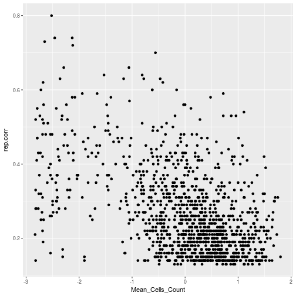

```r
library(ggplot2)
Pf.cmpd$data %>% ggplot2::ggplot(., aes(x = Mean_Cells_Count, rep.corr)) + ggplot2::geom_point()
```

```r
cor(Pf.cmpd$data[,c("Mean_Cells_Count", "rep.corr")])
```

```
##                  Mean_Cells_Count   rep.corr
## Mean_Cells_Count        1.0000000 -0.4955908
## rep.corr               -0.4955908  1.0000000
```

```r
nl <- c()
pb <- progress::progress_bar$new(total = N)
if (exists("cls")) {
  cls.gene <- cls
} else {
  cls.gene <- Pf.gene$data$Treatment %>% as.list()
}

library(foreach)
library(doMC)
doMC::registerDoMC(cores = 64)

nl <- foreach (i = 1:N) %dopar% {
  res <- sample.tot(Pf.cmpd = Pf.cmpd, Pf.gene = Pf.gene, random.shuffle = F, random.shuffle.genes = T, random.shuffle.cmpds = F, verbose = F, cor.thr = cor.thr, how.many = no.top.matches)
  length(res$genes)
}

nl <- unlist(nl)

print(mean(nl))
```

```
## [1] 5.47
```

```r
print(quantile(nl, 0.95))
```

```
##  95%
## 8.05
```

```r
max(nl)
```

```
## [1] 11
```